# PanelMatchSimulations

## Loading packages

```r
# clean slate
rm(list=ls())
options(digits=4)
# library(devtools)
# install_github("insongkim/wfe", ref = "new_branch")
# load packages
pkg <- c("wfe", "ggplot2", "plm", "pforeach", "scales", "ggplot2",
         "gridExtra")
lapply(pkg, require, character.only = TRUE)
setwd("/Users/EHW/Dropbox/w2fe/Simulations/results")
```

## Roadmap

This document reports simulation results for point estimates and coverage rate constructed with the following different methods:  
1. `PanelMatch` with weights supplied by synthetic control  
2. `PanelMatch` with weights supplied by Mahalanobis distance matching  
3. `PanelMatch` with weights supplied by propensity score weighting  
4. `PanelMatch` with weights supplied by Covariate Balancing Propensity Score (CBPS) weighting 5. OLS regression including lagged DV as well as two-way FE as a benchmark  
The first section reports results for settings where the models are correctly specified; the second section reports results for settings where the models are *misspecified*.

## Performance When Models are Correctly Specified

### Simulation Set-up:

The primary DGP is the following.  
We first draw two-way fixed effects prior to simulations:  
$\alpha_{i} \sim Normal(\mu = 10, \sigma^{2} = 6)$  
$\gamma_{t} \sim Normal(\mu = 10, \sigma^{2} = 6)$  
Then, we generate the data using the apriori fixed effects for each simulation:  
$Y_{i,t} = \rho_{1}Y_{i, t-1} + \delta_{1}*X_{1i,t} + \omega_{1}*X_{2i,t} + \beta T_{it} + \tau_{1}*T_{i, t-1} + \alpha_{i} + \gamma_{t} + \epsilon_{it}$  
$T_{it} \sim Bernoulli(1 - \frac{P_{it}}{1.3})$  
$logit(P_{it}) = \rho_{2}*Y_{i, t-1} + \delta_{2}* X_{1it} + \omega_{2}*X_{2i,t} + \tau_{2}*T_{i, t-1} + \alpha_{i} + \gamma_{t}$  
$X_{1it} = .75* X_{1i,t-1} + 0*\alpha_{i} + 0*\gamma_{t} + z_{it}$ $\epsilon_{it} = \phi_{e} * \epsilon_{i, t-1} + u_{it}$  
$\epsilon_{i,t = 1} \sim Normal(\mu = 0, \sigma^{2} = 6)$  
$u_{it} \sim Normal(\mu = 0, \sigma^{2} = unif(3,6))$  
$z_{it} \sim Normal(\mu = 3, \sigma^{2} = 1)$

The true treatment effect is $\beta = 1$. We let $\rho_{1} = \rho_{2} = 0.6$, letting the outcome at $t-1$ be highly correlated with both outcome at $t$ and treatment at $t$. We set $\delta_{1} = 0.2$ and $\delta_{2} = 0.4$ so that both outcome and treatment at $t$ are affected by a continuous covariate, $X_{1}$, to some extent. $X_{1}$ is also serially correlated itself but not correlated with the fixed effects. We let $\omega_{1} = \omega_{2} = 0$, so that another covariate $X_{2}$ is not going to affect our data generating process at all for either outcome or treatment. We let $\tau_{1} = \tau_{2} = 0$, so that neither the outcome nor treatment at $t$ is affected by treatment at $t-1$.  
In other words, this data generating process stipulates that the current outcome is affected by both past outcome and current treatment, and current treatment itself is also affected by past outcome. Both treatment and outcome are also affected by a continuous covariate and two-way fixed effects. Note that we make the error structure both heteroskedastic, by allowing the variance of $u$ to follow a uniform distribution, and serially corrleated, by setting $\phi_{e} = 0.5$.  
For each simulation, we will compute WFE regression standard errors. We try $M = 1$ for Mahalanobis matching throughout the simulation, but try both $L = 6$ and $L = 4$ for lag length.

### Model Specification

For OLS, we fit the following, two-way FE model: $Y_{it} = \rho_{1}Y_{i, t-1} + \beta T_{it} + \delta_{1} X_{1it} + \alpha_{i} + \gamma_{t} + \epsilon_{it}$  
For our methods based on synthetic control weighting and mahalanobis distance matching, we use $T_{it}$ and $X_{1it}$ for each matched set; for our methods based on regular propensity score weighting and CBPS weighting, we use $Y_{i, t-1}$ and $X_{it}$ as predictors of $T_{it}$.

### Bias and RMSE Computation

We compute bias in the following way:  
$\frac{1}{B}\sum_{b = 1}^{B}\hat{\beta_{b}}-\beta$  
We compute root mean squared error (RMSE) in the following way:  
$\frac{1}{B}\sum_{b = 1}^{B} \sqrt{(\hat{\beta_{b}}-\beta)^2}$

### Results for Correctly Specified Models

#### Bias

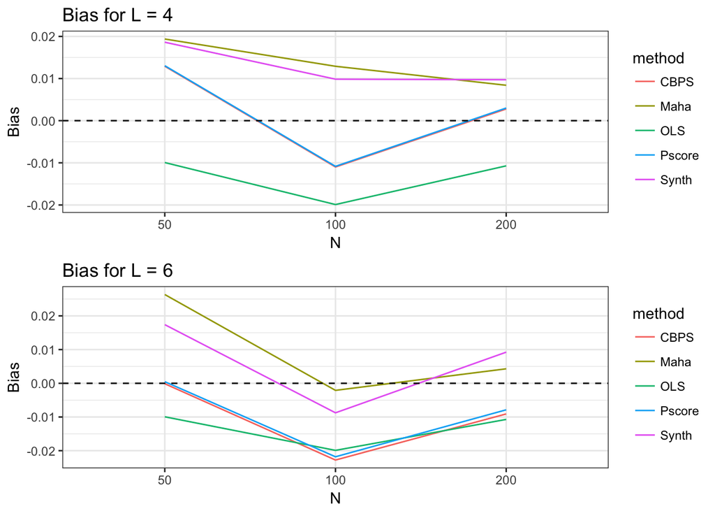

#### RMSE

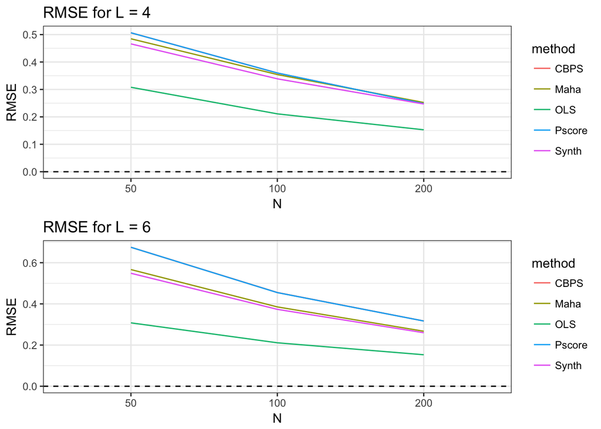

#### SD of Point Estimates

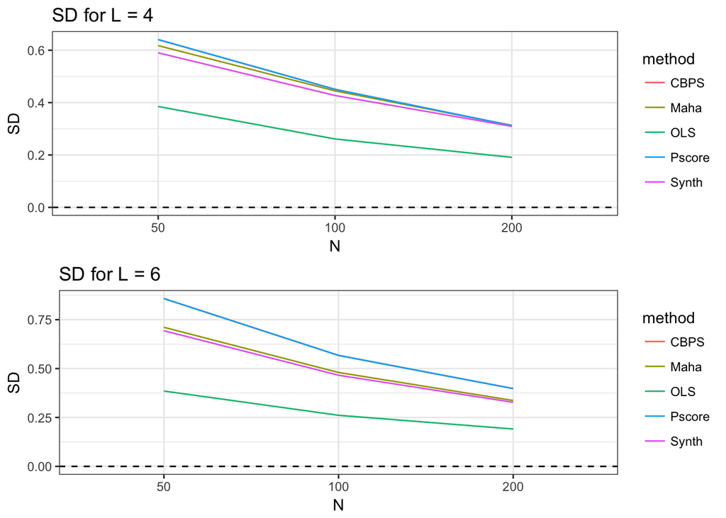

#### Coverage

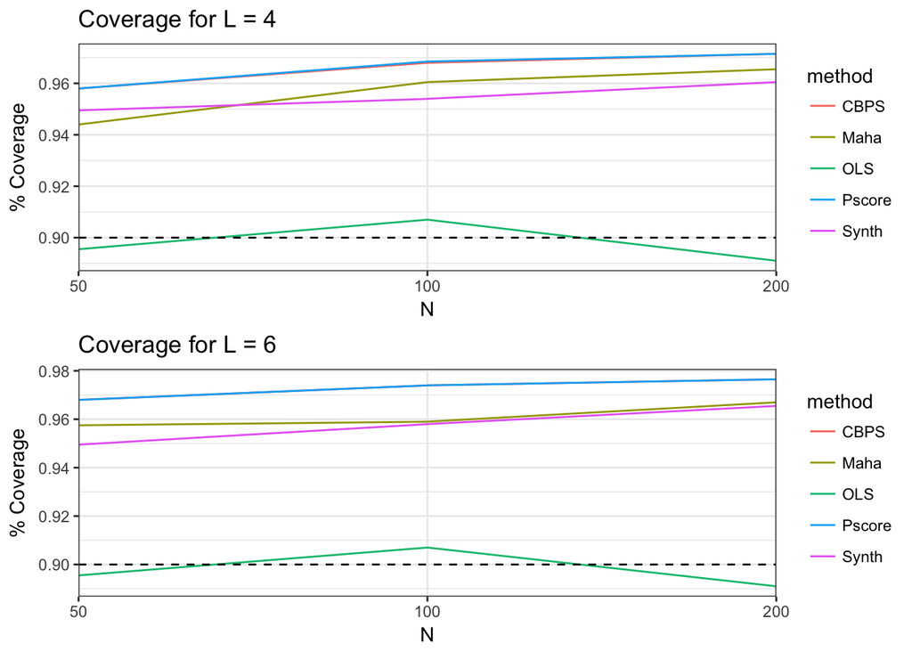

## Performance under Model Misspecification

### Simulation Set-up:

In this section, we report results from *misspecified models*. The new DGP differs from the primary DGP only in the following way: in both the outcome model and the treatment model, we replace $X_{1it}$ with $X_{1it}^2$. The new DGP is detailed below:  
We first draw two-way fixed effects prior to simulations:  
$\alpha_{i} \sim Normal(\mu = 10, \sigma^{2} = 6)$  
$\gamma_{t} \sim Normal(\mu = 10, \sigma^{2} = 6)$  
Then, we generate the data using the apriori fixed effects for each simulation:  
$Y_{i,t} = \rho_{1}Y_{i, t-1} + \delta_{1}*X_{1i,t}^2 + \omega_{1}*X_{2i,t} + \beta T_{it} + \tau_{1}*T_{i, t-1} + \alpha_{i} + \gamma_{t} + \epsilon_{it}$  
$T_{it} \sim Bernoulli(1 - \frac{P_{it}}{1.3})$  
$logit(P_{it}) = \rho_{2}*Y_{i, t-1} + \delta_{2}* X_{1it}^2 + \omega_{2}*X_{2i,t} + \tau_{2}*T_{i, t-1} + \alpha_{i} + \gamma_{t}$  
$X_{1it} = .75* X_{1i,t-1} + 0*\alpha_{i} + 0*\gamma_{t} + z_{it}$ $\epsilon_{it} = \phi_{e} * \epsilon_{i, t-1} + u_{it}$  
$\epsilon_{i,t = 1} \sim Normal(\mu = 0, \sigma^{2} = 6)$  
$u_{it} \sim Normal(\mu = 0, \sigma^{2} = unif(3,6))$  
$z_{it} \sim Normal(\mu = 3, \sigma^{2} = 1)$  
As done for the primary DGP, in the current DGP we let $\rho_{1} = \rho_{2} = 0.6$, set $\delta_{1} = 0.2$ and $\delta_{2} = 0.4$, and let $\omega_{1} = \omega_{2} = \tau_{1} = \tau_{2} = 0$

### Model (Mis)Specification

For OLS, we fit the following, two-way FE model: $Y_{it} = \rho_{1}Y_{i, t-1} + \beta T_{it} + \delta_{1} X_{1it} + \alpha_{i} + \gamma_{t} + \epsilon_{it}$  
For our methods based on synthetic control weighting and mahalanobis distance matching, we use $T_{it}$ and $X_{1it}$ for each matched set; for our methods based on regular propensity score weighting and CBPS weighting, we use $Y_{i, t-1}$ and $X_{it}$ as predictors of $T_{it}$.  
*Note that* since our model specifications for both OLS and `PanelMatch` remain the same as those for the primary DGP but our current DGP differs by replacing $X$ with its squared term, our models for the current DGP are *misspecified*.

### Bias and RMSE Computation

We compute bias in the following way:  
$\frac{1}{B}\sum_{b = 1}^{B}\hat{\beta_{b}}-\beta$  
We compute root mean squared error (RMSE) in the following way:  
$\frac{1}{B}\sum_{b = 1}^{B} \sqrt{(\hat{\beta_{b}}-\beta)^2}$

### Results for misspecified models

#### Bias (for misspecified models)

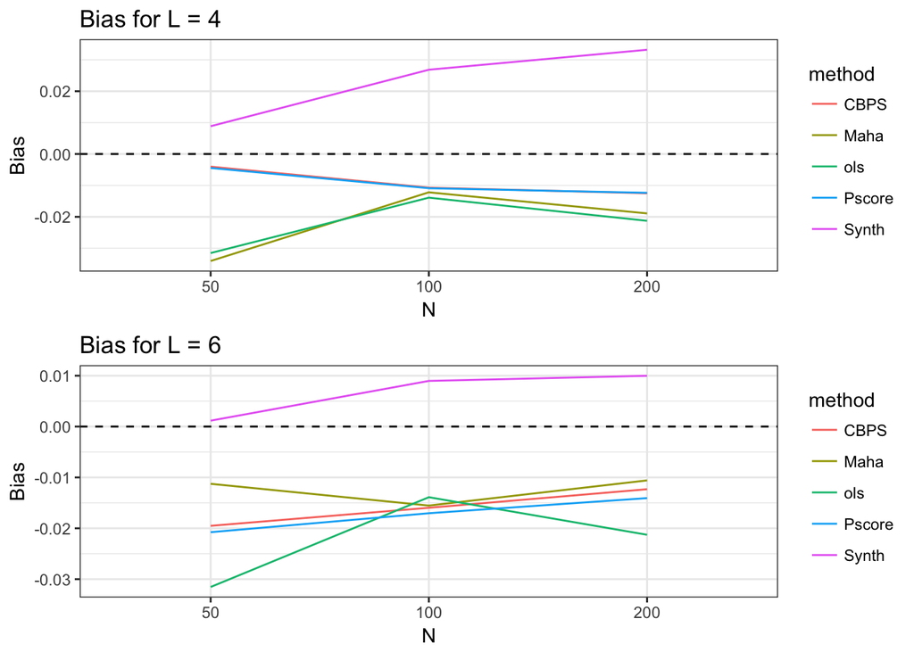

#### RMSE (for misspecified models)

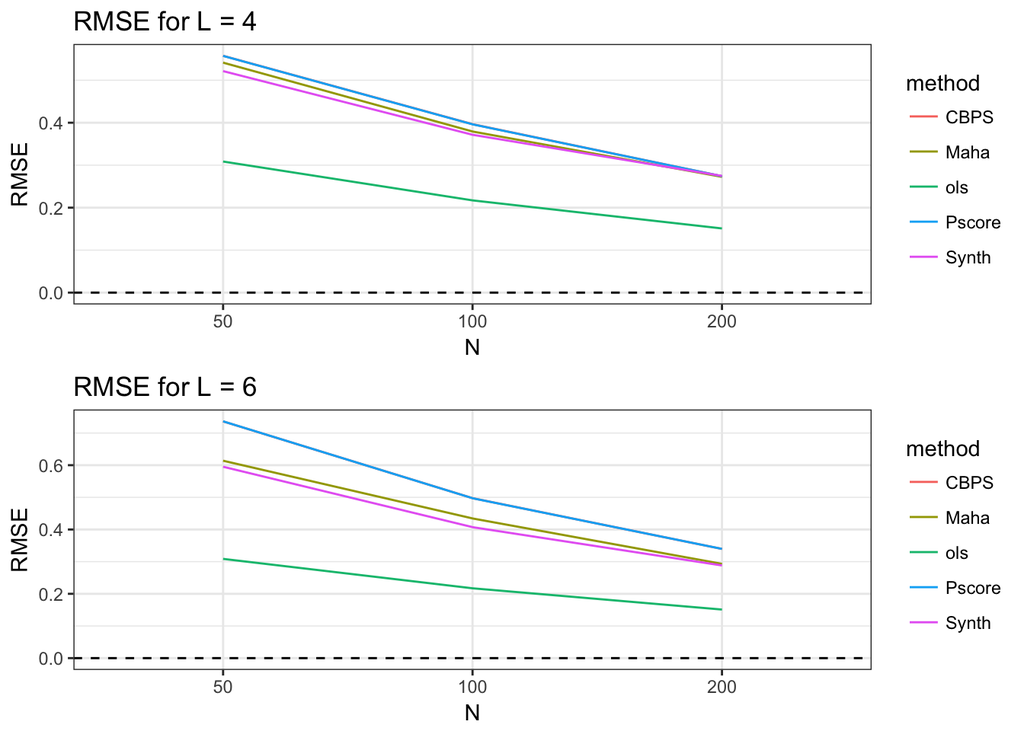

#### SD of Point Estimates (for misspecified models)

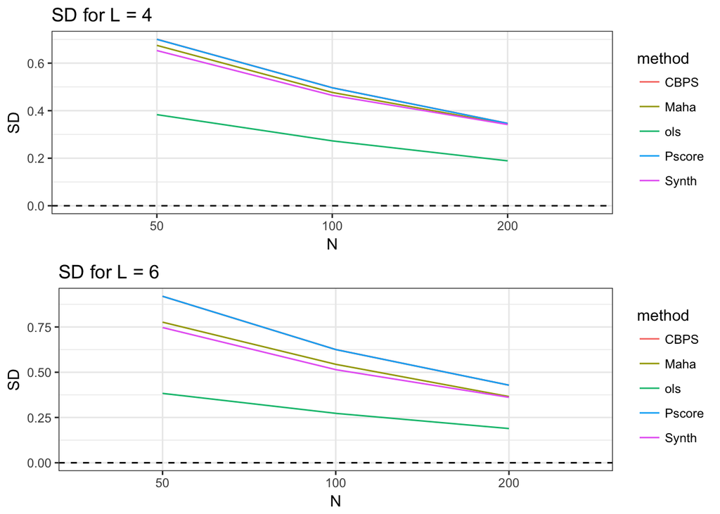

#### Coverage (for misspecified models)

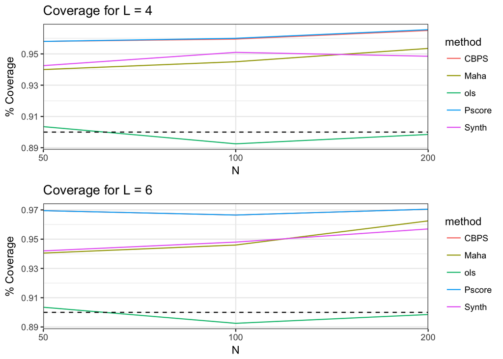